# A. INTRODUCTION

## D12. String Formatting

Di sini kita akan mempelajari tentang cara-cara format string.

Ada tiga cara melakukan format pada string. Pertama dengan menggunakan fungsi format(), yang kedua dengan f"...", dan ketiga dengan menggunakan cara lama (menggunakan %).

##### Cara format()

Memformat string dengan fungsi format() dibuat dengan menggunakan tanda {} sebagai placeholder atau posisi substring yang akan digantikan. Kita biasa menggunakan argumen posisi atau kata kunci untuk menunjukkan urutan dari substring.

```python
# menggunakan posisi default
default_order = "nama saya {}, teman saya {} dan {}".format("Budi", "Galih","Ratna")
print('\n--- Urutan default ---')
print(default_order)
```

```
--- Urutan default ---
nama saya Budi, teman saya Galih dan Ratna
```

```python
# menggunakan argument posisi
positional_order = "nama saya {1}, teman saya {0} dan {2}".format("Budi", "Galih","Ratna")
print('\n--- Urutan berdasarkan posisi ---')
print(positional_order)
```

```
--- Urutan berdasarkan posisi ---
nama saya Galih, teman saya Budi dan Ratna
```

Metode format() dapat memiliki spesifikasi format opsional. Misalnya, kita bisa menggunakan tanda < untuk rata kiri, > untuk rata kanan, ^ untuk rata tengah, dan sebagainya.

```python
#Format integer
print("{0} bila diubah jadi biner menjadi {0:b}".format(12))

#Format float
print("Format eksponensial: {0:e}".format(1566.345))

#Pembulatan
print("Sepertiga sama dengan: {0:.3f}".format(1/3))

#Meratakan string
print("|{:<10}|{:^10}|{:>10}|".format('beras', 'gula', 'garam'))
```

```
12 bila diubah jadi biner menjadi 1100
Format eksponensial: 1.566345e+03
Sepertiga sama dengan: 0.333
|beras     |   gula   |     garam|
```

##### Cara f"..."

Hampir sama dengan format(), Memformat string dengan cara ini juga dibuat dengan menggunakan tanda {} sebagai placeholder atau posisi substring yang akan digantikan.

```python
nama = "Zein"
kampus = "UTY"
Jabatan = "CEO"

print(f"nama saya {nama}, saya lulusan {kampus}, jabatan saya {Jabatan}")
```

```
nama saya Zein, saya lulusan UTY, jabatan saya CEO
```

##### Cara %

Kita juga bisa menggunakan cara lama, yaitu dengan memanfaatkan operator % untuk melakukan format string.

```python
nama = 'Budi'
print('Nama saya %s' %nama)
```

```
Nama saya Budi
```

## D13. Tipe Data Sequence : List & Tuple

### List

Tipe data ini digunakan untuk menampung sekumpulan data secara terorganisir. List dan tuple merupakan bentuk dari tipe data sequence.

Tipe data list diawali dengan tanda kurung siku buka ( [ ), memisahkan setiap elemen di dalamnya dengan tanda koma ( , ) dan ditutup dengan kurung siku tutup ( ] ).

Contoh :

```
contoh_list = [1, 'dua', 3, 4.0, 5 ]
```

Setiap elemen dari list memiliki indeks yang dimulai dari angka 0 dan terus bertambah satu nilainya hingga elemen terakhir dari list.

```python
contoh_list = [1, 'dua', 3, 4.0, 5]
print (contoh_list[0]) # Akan menampilkan angka 1
print (contoh_list[1]) # Akan menampilkan string 'dua'
```

```
1
dua
```

Tipe data list bersifat mutable yang berarti setiap elemen di dalam list dapat dirubah nilainya setelah proses pendeklarasian list.

```python
contoh_list = [1, 'dua', 3, 4.0, 5 ]
print(contoh_list[3]) # Akan menampilkan angka 4.0
contoh_list[3] = 'empat'

print(contoh_list[3]) # Akan menampilkan string "empat" karena telah diubah nilainya
```

```
4.0
empat
```

### Tuple

Tipe data tuple juga berfungsi untuk menampung sekumpulan data. Tipe data tuple diawali dengan tanda kurung buka ( ( ), memisahkan setiap elemen di dalamnya dengan tanda koma ( , ) dan ditutup dengan tanda kurung tutup ( ) ).

Contoh :

```
contoh_tuple = ('Januari', 'Februari', 'Maret','April')
```

Aturan indeks dan cara mengakses elemen pada sebuah tuple serupa dengan list.

```python
contoh_tuple = ('Januari', 'Februari', 'Maret','April')
print(contoh_tuple[2]) # Akan menampilkan 'Maret'
```

```
Maret
```

Berbeda dengan tipe data list, tipe data tuple bersifat immutable yang berarti elemen pada tipe data tuple tidak dapat diubah setelah proses pendeklarasiannya. Ketika dirubah maka akan error.

```python
contoh_tuple = ('Januari', 'Februari', 'Maret','April')
contoh_tuple[2] = 'Desember'
```

```
---------------------------------------------------------------------------
TypeError                                 Traceback (most recent call last)
<ipython-input-15-0d118b4ef669> in <module>
      1 contoh_tuple = ('Januari', 'Februari', 'Maret','April')
----> 2 contoh_tuple[2] = 'Desember'

TypeError: 'tuple' object does not support item assignment
```

## D14. Tipe Data Sets

### Set

Serupa dengan tipe data sequence, tipe data set digunakan untuk menampung sekumpulan data dengan tipe lainnya. Terdapat dua jenis dari tipe data set yaitu, set dan frozenset.

Tipe data set diawali dengan tanda kurung buka kurawal ( { ), memisahkan setiap elemen di dalamnya dengan tanda koma ( , ) dan ditutup dengan tanda kurung tutup ( } ). Namun, berbeda dengan tipe data sequence, seperti list, tipe data objek tidak mengizinkan adanya elemen dengan nilai yang sama dan tidak memperdulikan urutan dari elemen.

Contoh :

```python
#LIST
contoh_list = ['Dewi', 'Budi', 'Cici', 'Linda', 'Cici']
print(contoh_list)
```

```
['Dewi', 'Budi', 'Cici', 'Linda', 'Cici']
```

```python
#SET
contoh_set = {'Dewi', 'Budi', 'Cici', 'Linda', 'Cici'}
print(contoh_set)
```

```
{'Budi', 'Linda', 'Cici', 'Dewi'}
```

Dari kedua contoh output pada program, dapat terlihat:

- Berbeda dengan tipe data set, tipe data list memperdulikan urutan dari setiap elemen saat list dideklarasikan.
- Berbeda dengan list yang mengizinkan adanya duplikasi elemen, tipe data set tidak mengizinkan adanya elemen dengan nilai yang sama di dalamnya.

### Fozenset

```python
contoh_frozen_set = ({'Dewi', 'Budi', 'Cici', 'Linda', 'Cici'})
print(contoh_frozen_set)
```

```
{'Budi', 'Linda', 'Cici', 'Dewi'}
```

## D15. Mapping Type : Dictionary

Tipe data mapping dapat digunakan untuk memetakan sebuah nilai ke nilai lainnya. Dalam Python, tipe data mapping disebut dengan istilah dictionary. Tipe data dictionary dapat dideklarasikan dengan diawali oleh tanda kurung buka kurawal ( { ), memisahkan setiap elemen di dalamnya dengan tanda koma ( , ) dan ditutup dengan tanda kurung tutup ( } ). Setiap elemen pada tipe data dictionary dideklarasikan dengan format:

"kunci" : "nilai"

Hal inilah yang membedakan tipe data mapping dengan tipe data set. Untuk lebih memperjelas tipe data mapping, perhatikan contoh berikut

```python
person = {'nama': 'John Doe', 'pekerjaan': 'Programmer'}
```

Potongan kode di atas adalah contoh pendeklarasian dari tipe data dictionary. Kemudian, bagaimana dengan cara mengakses informasi dari tipe data ini? Perhatikan potongan kode berikut

```python
print(person['nama'])
print(person['pekerjaan'])
```

```
John Doe
Programmer
```

# TUGAS PRAKTIK 1

Pada TP1 ini, kita diberi misi untuk membuat program kalkulator potongan harga untuk beberapa barang sekaligus dengan memanfaatkan semua ilmu yang telah dipelajari sebelumnya.

Ketentuan nama barang, harga barang, dan diskon ada di tabel berikut :

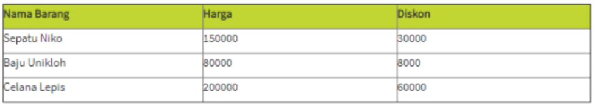

#### Misi 1

Product Manager meminta kita untuk membungkus data dalam tabel ke dalam sebuah variabel.

Hint :

- Presentasikan data dalam tabel di atas ke dalam variabel dictionary!

```python
#Presentasi informasi barang
sepatu = {"nama": "Sepatu Niko", "harga": 150000, "diskon": 30000}
baju = {"nama": "Baju Unikloh", "harga": 80000, "diskon": 8000}
celana = {"nama": "Celana Lepis", "harga": 200000, "diskon": 60000}
```

#### Misi 2

Product Manager meminta kita untuk mempresentasikan data informasi barang yang telah di dibungkus dalam variabel.

Hint:

- Deklarasikan daftar belanjaan ke dalam tipe data list!

```python
#Membungkus data informasi barang ke dalam variabel bertipe data dictionary
sepatu = {"nama": "Sepatu Niko", "harga": 150000, "diskon": 30000}
baju = {"nama": "Baju Unikloh", "harga": 80000, "diskon": 8000}
celana = {"nama": "Celana Lepis", "harga": 200000, "diskon": 60000}

#Presentasi daftar belanjaan
daftar_belanja = [sepatu, baju, celana]
print(daftar_belanja)
```

```
[{'nama': 'Sepatu Niko', 'harga': 150000, 'diskon': 30000}, {'nama': 'Baju Unikloh', 'harga': 80000, 'diskon': 8000}, {'nama': 'Celana Lepis', 'harga': 200000, 'diskon': 60000}]
```

Selanjutnya, Product Manager meminta kita untuk menghitung total harga jual dengan potongan harga. Tak lupa menyertakan pajak sebesar 10% dari nilai jual.

Di sini kita diberi tips oleh Product Manager untuk menyelesaikan tugas ini:

1. Data yang dinyatakan ke dalam dictionary
2. Hitung harga masing-masing data setelah dikurangi diskon
3. Hitung harga total
4. Hitung harga kena pajak
5. Cetak total_harga + total_pajak

```python
# Data yang dinyatakan ke dalam dictionary
sepatu = {"nama": "Sepatu Niko", "harga": 150000, "diskon": 30000}
baju = {"nama": "Baju Unikloh", "harga": 80000, "diskon": 8000}
celana = {"nama": "Celana Lepis", "harga": 200000, "diskon": 60000}

# Hitunglah harga masing-masing data setelah dikurangi diskon
harga_sepatu = sepatu["harga"] - sepatu["diskon"]
harga_baju = baju["harga"] - baju["diskon"]
harga_celana = celana["harga"] - celana["diskon"]

# Hitung harga total
total_harga = harga_sepatu + harga_baju + harga_celana

# Hitung harga kena pajak
total_pajak = total_harga * 0.1

# Cetak total_harga + total_pajak
print(total_harga + total_pajak)
```

```
365200.0
```

.

.

# E. OPERATORS

## E1. Aritmetic Operators

Operator arithmetic digunakan pada tipe data numerik, untuk melakukan operasi matematika sederhana yang terdiri atas:

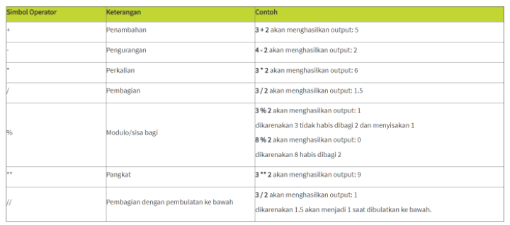

## E2. Assignment Operators

Operator assignment digunakan untuk mendeklarasikan nilai secara langsung ke suatu variabel.

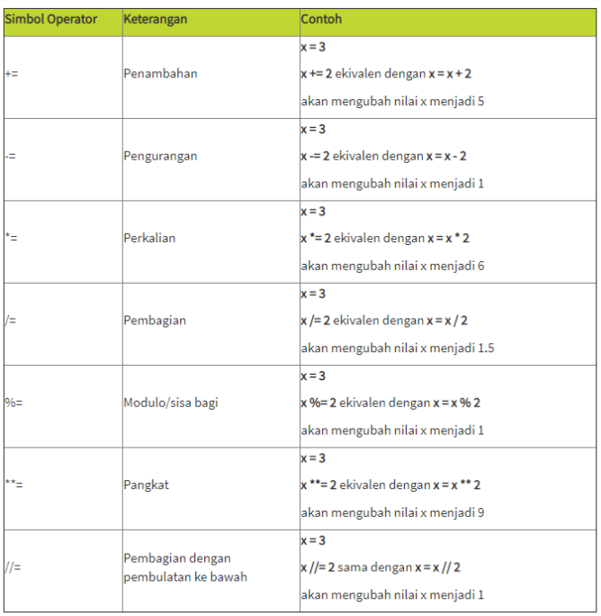

```python
#Example1
bil1 = 5
bil2 = bil1 // 2
print(bil2)
```

```
2
```

```python
#Example2
bil1 = 5
bil2 = bil1 % 2
bil1 *= bil2
print(bil1)
```

```
5
```

## E3. Comparison Operators

Operator comparison dapat digunakan untuk membandingkan dua buah nilai, berikut merupakan contoh-contoh operator komparasi.

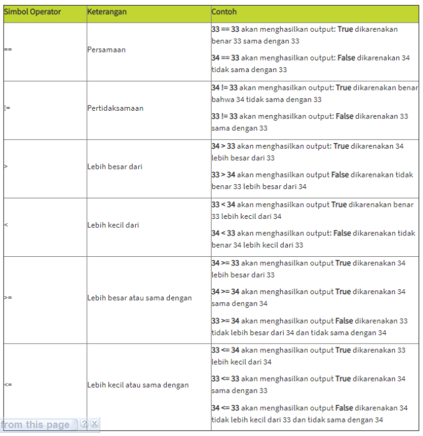

## E4. Logical Operators

Operator logical digunakan untuk menggabungkan beberapa nilai kebenaran atas suatu statemen logika.

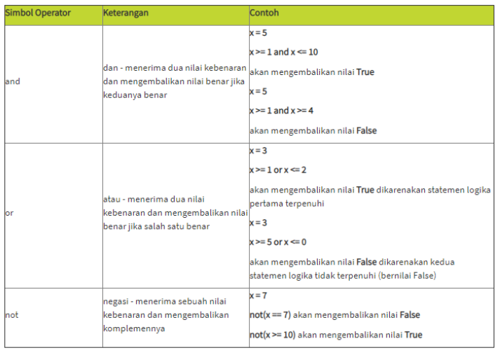

```python
#Example
bil1 = 5
bil2 = 9
print(bil2 > bil1 and bil2 < 15)
```

```
True
```

```python
#Example
bil1 = 5
bil2 = bil1 // 2
hasil = bil1 == 1 and bil1 < bil2
print(hasil)
```

```
False
```